# Legos2

Pablo

2025-01-25

```r
setwd("C:/Users/pablo/OneDrive/Escritorio/Portfolio/R/lego_data")
```

# 1 Lego

Cargamos los datos:

```r
data <- read.csv("lego_population_cof.csv")
```

Cargamos las librerías:

```r
suppressPackageStartupMessages(library(tidytable))
```

```r
suppressPackageStartupMessages(library(data.table))
suppressPackageStartupMessages(library(ggplot2))
suppressPackageStartupMessages(library(skimr))
suppressPackageStartupMessages(library(forcats))
suppressPackageStartupMessages(library(dplyr))
suppressPackageStartupMessages(library(mice))
suppressPackageStartupMessages(library(naniar))
suppressPackageStartupMessages(library(corrplot))
```

## 1.1 Análisis descriptivo y limpieza de los datos

Para hacernos una idea general del conjunto de datos veremos:

```r
# Primero vemos su estructura

str(data)
```

```
## 'data.frame':    2307 obs. of  16 variables:
##  $ X            : int  1 2 3 4 5 6 7 8 9 10 ...
##  $ Item_Number  : chr  "-" "-" "-" "-" ...
##  $ Set_Name     : chr  NA NA NA NA ...
##  $ Amazon_Price : chr  "" "" "-" "-" ...
##  $ Year         : int  NA NA NA NA NA NA NA NA NA NA ...
##  $ Pages        : logi  NA NA NA NA NA NA ...
##  $ unique_pieces: int  NA NA NA NA NA NA NA NA NA NA ...
##  $ Theme        : chr  NA NA NA NA ...
##  $ Pieces       : int  NA NA NA NA NA NA NA NA NA NA ...
##  $ Price        : logi  NA NA NA NA NA NA ...
##  $ Ages         : chr  "Ages_NA" "Ages_NA" "Ages_NA" "Ages_NA" ...
##  $ Minifigures  : int  NA NA NA NA NA NA NA NA NA NA ...
##  $ Packaging    : chr  NA NA NA NA ...
##  $ Weight       : chr  NA NA NA NA ...
##  $ Availability : chr  NA NA NA NA ...
##  $ Size         : chr  NA NA NA NA ...
```

```r
#Vemos las filas y columnas del dataset

dim(data)
```

```
## [1] 2307   16
```

Vamos a realizar una breve descripción de cada variable del conjunto de datos:

X: Un índice numérico que identifica cada observación en el conjunto de datos.

Item_Number: El número de identificación único para cada juego de LEGO.

Set_Name: El nombre del conjunto de LEGO.

Amazon_Price: El precio del conjunto de LEGO en la plataforma de Amazon.

Year: El año de lanzamiento del conjunto de LEGO.

Pages: El número de páginas del conjunto de instrucciones del juego.

unique_pieces: El número total de piezas únicas en el conjunto de LEGO.

Theme: El tema al que pertenece el conjunto de LEGO.

Pieces: El número total de piezas en el conjunto de LEGO.

Price: El precio del conjunto de LEGO.

Ages: La edad recomendada para jugar con el conjunto de LEGO.

Minifigures: El número de minifiguras incluidas en el conjunto de LEGO.

Packaging: El tipo de embalaje del conjunto de LEGO.

Weight: El peso del conjunto de LEGO.

Availability: La disponibilidad del conjunto de LEGO.

Size: El tamaño del conjunto de LEGO.

```r
# Vemos si hubiera algún dato duplicado,

anyDuplicated(data)
```

```
## [1] 0
```

```r
DT <- as.data.table(data)
#Primeras filas

DT %>% slice_head(n = 6) %>% as.data.table() %>% head()
```

```
##    X Item_Number Set_Name Amazon_Price Year Pages unique_pieces Theme Pieces
## 1: 1           -     <NA>                NA    NA            NA  <NA>     NA
## 2: 2           -     <NA>                NA    NA            NA  <NA>     NA
## 3: 3           -     <NA>            -   NA    NA            NA  <NA>     NA
## 4: 4           -     <NA>            -   NA    NA            NA  <NA>     NA
## 5: 5           -     <NA>       €50.90   NA    NA            NA  <NA>     NA
## 6: 6           -     <NA>       €45.04   NA    NA            NA  <NA>     NA
##    Price    Ages Minifigures Packaging Weight Availability Size
## 1:    NA Ages_NA          NA      <NA>   <NA>         <NA> <NA>
## 2:    NA Ages_NA          NA      <NA>   <NA>         <NA> <NA>
## 3:    NA Ages_NA          NA      <NA>   <NA>         <NA> <NA>
## 4:    NA Ages_NA          NA      <NA>   <NA>         <NA> <NA>
## 5:    NA Ages_NA          NA      <NA>   <NA>         <NA> <NA>
## 6:    NA Ages_NA          NA      <NA>   <NA>         <NA> <NA>
```

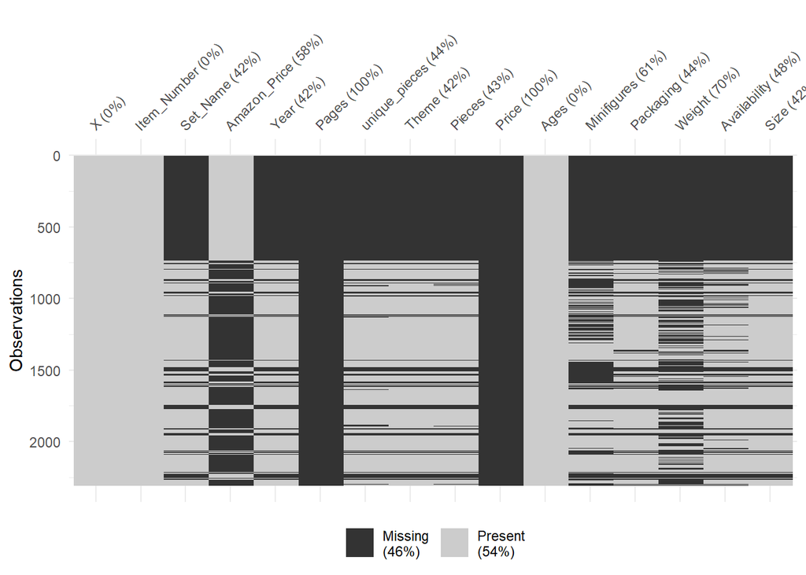

```r
# Crear el gráfico de mosaico de valores faltantes
vis_miss(data)
```

```r
# Siendo 'data' es el nombre de los datos y 'DT' es el data.table correspondiente


desc_DT <- skim(DT)

var_type_missing_DT <- desc_DT %>%
  mutate(n_missing_perc = 100 * round(1-complete_rate, 3)) %>%
  select(skim_type, skim_variable, n_missing, n_missing_perc) %>%
  arrange(skim_type, n_missing)

print(var_type_missing_DT)
```

```
## ── Data Summary ────────────────────────
##                            Values
## Name                       DT
## Number of rows             2307
## Number of columns          16
## Key                        NULL
## _______________________
## Column type frequency:
##   character                9
##   logical                  2
##   numeric                  5
## ________________________
## Group variables            None
##
## ── Variable type: character ────────────────────────────────────────────────────
##   skim_variable n_missing n_missing_perc
## 1 Item_Number           0            0
## 2 Ages                  0            0
## 3 Set_Name            974           42.2
## 4 Size                974           42.2
## 5 Theme               977           42.3
## 6 Packaging          1014           44
## 7 Availability       1101           47.7
## 8 Amazon_Price       1333           57.8
## 9 Weight             1616           70
##
## ── Variable type: logical ──────────────────────────────────────────────────────
##   skim_variable n_missing n_missing_perc
## 1 Pages              2307            100
## 2 Price              2307            100
##
## ── Variable type: numeric ──────────────────────────────────────────────────────
##   skim_variable n_missing n_missing_perc
## 1 X                     0            0
## 2 Year                974           42.2
## 3 Pieces              986           42.7
## 4 unique_pieces      1008           43.7
## 5 Minifigures        1398           60.6
```

Este resumen de datos proporciona una visión general de la estructura del conjunto de datos, incluyendo el número de filas y columnas o los tipos de datos presentes. Esto es útil para comprender la naturaleza y la organización de los datos antes de realizar un análisis más detallado.

```r
data_wonulls <- data %>% drop_na()

round(1 - nrow(data_wonulls) / nrow(data), 3)*100
```

```
## [1] 100
```

Todos los datos en el conjunto original (data) tienen valores faltantes y por lo tanto, al eliminar los valores faltantes, no quedarían filas en data_wonulls

Vemos que las variables “Pages” y “Price” tienen un 100% de valores faltantes por lo que procederemos a eliminar dichas variables. La variable X es simplemente un índice numérico que identifica cada observación en el conjunto de datos y no aporta información adicional para tu análisis, por lo que también la eliminaremos.

```r
DT <- select(DT, -c(Pages, Price, X)) #Weight, Minifigures, X, Item_Number))
```

Observamos en los datos una reducción significativa en la cantidad de valores faltantes a partir de la fila 731.

```r
# Intervalo 1-730
porcentaje_faltantes_intervalo1 <- mean(rowMeans(is.na(DT[1:730])) * 100, na.rm = TRUE)

# Intervalo 731-2307
porcentaje_faltantes_intervalo2 <- mean(rowMeans(is.na(DT[731:2307])) * 100, na.rm = TRUE)

# Intervalo 1-2307
porcentaje_faltantes_total <- mean(rowMeans(is.na(DT)) * 100, na.rm = TRUE)

# Imprimir los resultados
print(porcentaje_faltantes_intervalo1)
```

```
## [1] 76.92308
```

```r
print(porcentaje_faltantes_intervalo2)
```

```
## [1] 24.65733
```

```r
print(porcentaje_faltantes_total)
```

```
## [1] 41.19569
```

Por lo tanto, consideramos pertinente filtrar el dataset, conservando únicamente las filas del segundo intervalo.

```r
DT <- filter(DT, row_number() > 730)
```

Veamos graficamente la distribución de los valores faltantes con la selección del segundo intervalo.

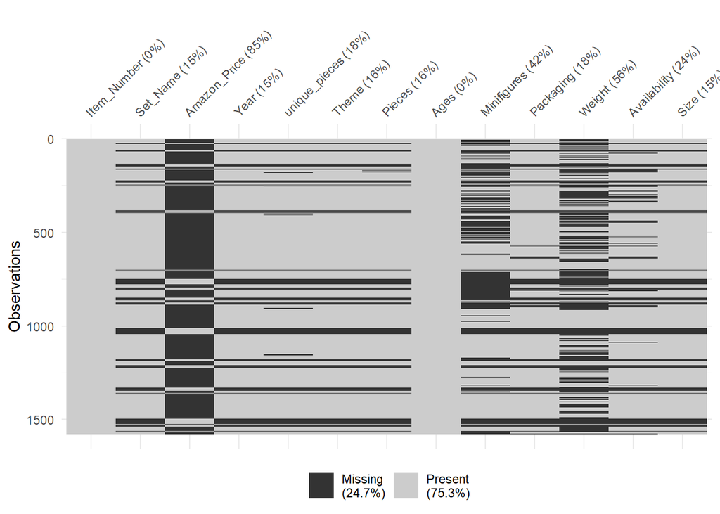

```r
# Crear el gráfico de mosaico de valores faltantes
vis_miss(DT)
```

A continuación veremos la estructura actual de los datos después de la selección del segundo intervalo.

```r
str(DT)
```

```
## Classes 'data.table' and 'data.frame':   1577 obs. of  13 variables:
##  $ Item_Number  : chr  "10260" "10261" "10262" "10263" ...
##  $ Set_Name     : chr  "Downtown Diner" "Roller Coaster" "James Bond Aston Martin DB5" "Winter Village Fire Station" ...
##  $ Amazon_Price : chr  NA NA NA NA ...
##  $ Year         : int  2018 2018 2018 2018 2019 2019 2019 2019 2018 2019 ...
##  $ unique_pieces: int  507 556 311 323 564 359 194 328 229 303 ...
##  $ Theme        : chr  "Creator Expert" "Creator Expert" "Creator Expert" "Creator Expert" ...
##  $ Pieces       : int  2480 4124 1290 1166 2569 1471 1087 1477 826 1023 ...
##  $ Ages         : chr  "Ages_16+" "Ages_16+" "Ages_NA" "Ages_12+" ...
##  $ Minifigures  : int  6 11 NA 8 6 NA 2 2 3 NA ...
##  $ Packaging    : chr  "Box" "Box" "Box" "Box" ...
##  $ Weight       : chr  NA "5.8Kg (12.78 lb)" NA "1.37Kg (3.01 lb)" ...
##  $ Availability : chr  "LEGO exclusive" "LEGO exclusive" "LEGO exclusive" "LEGO exclusive" ...
##  $ Size         : chr  "Small" "Small" "Small" "Small" ...
##  - attr(*, ".internal.selfref")=<externalptr>
```

Hemos podido ver como ha cambiado significativamente la estructura y la distribución de los valores faltantes de nuestros datos. Ahora, continuaremos modelandolos haciendo algunas transformaciones.

```r
# Convertir la columna Amazon_Price a numérica, eliminando todos los valores que no sean números del 0-9 y el punto decimal

DT[, Amazon_Price := as.numeric(gsub("[^0-9.]", "", Amazon_Price))]
```

Convertimos variables integer en numeric

```r
DT[, c("Year", "unique_pieces", "Pieces", "Item_Number", "Minifigures") := lapply(.SD, as.numeric), .SDcols = c("Year", "unique_pieces", "Pieces", "Item_Number", "Minifigures")]
```

Para simplificar la variable “Weight”, procedemos a extraer sus valores en kilogramos y los almacenamos en una nueva columna denominada “Peso_Kg”. Posteriormente, eliminamos la variable original “Weight” del conjunto de datos.

```r
# Función para extraer solo el peso en kg
extraer_peso_kg <- function(peso) {
  # Eliminar todo entre paréntesis
  peso_sin_parentesis <- gsub("\\(.*?\\)", "", peso)

  # Eliminar caracteres no numéricos excepto la coma/punto decimal
  peso_kg <- gsub("[^0-9.,]", "", peso_sin_parentesis)

  # Convertir a tipo numérico
  as.numeric(peso_kg)
}

# Aplicar la función a la columna "Peso"
DT$Peso_Kg <- extraer_peso_kg(DT$Weight)

DT <- select(DT, -Weight)
```

Convertiremos las variables a factor, excepto Set_Name, al ser el nombre para cada juego

```r
# Convertir las columnas usando lapply
DT[, c("Theme", "Ages", "Packaging", "Availability", "Size", "Year") := lapply(.SD, as.factor), .SDcols = c("Theme", "Ages", "Packaging", "Availability", "Size", "Year")]
```

Tras este análisis inicial, observamos que aunque se ha reducido significativamente la cantidad de valores faltantes al eliminar el primer intervalo, aún persiste una cantidad considerable de datos faltantes. Por lo tanto, procederemos a realizar la imputación de estos valores para garantizar la integridad y la completitud de nuestros datos.

Imputación de las variables númericas:

```r
columnas_numericas <- c("unique_pieces", "Pieces", "Minifigures", "Amazon_Price")

# Imputamos con MICE
imp <- mice(DT[, c("unique_pieces", "Pieces", "Minifigures", "Amazon_Price")], m = 5, maxit = 50)
# Completamos el data table con las imputaciones realizadas
DT[, columnas_numericas] <- complete(imp)
```

```r
DT <- select(DT, -Item_Number)
```

Para imputar la variable Peso_Kg, partimos del sentido de pensar que existe una relación entre el peso del juego y la cantidad de piezas que tiene, ya que a medida que aumenta el número de piezas en un conjunto LEGO, es probable que también aumente su peso debido al material utilizado para fabricar las piezas adicionales.

Por ello, haremos una comprobación de la relación entre ambos y plantear la imputación de esta variable por una regresión lineal con la variable Piece.

```r
#Comprobamos si hay algún tipo de relación lineal entre el peso y la cantidad de piezas
modelo <- lm(Peso_Kg ~ Pieces, data = DT)
summary(modelo)
```

```
##
## Call:
## lm(formula = Peso_Kg ~ Pieces, data = DT)
##
## Residuals:
##     Min      1Q  Median      3Q     Max
## -3.3276 -0.1299 -0.0608  0.0651  5.6401
##
## Coefficients:
##              Estimate Std. Error t value Pr(>|t|)
## (Intercept) 1.082e-01  1.991e-02   5.436 7.57e-08 ***
## Pieces      1.395e-03  2.762e-05  50.499  < 2e-16 ***
## ---
## Signif. codes:  0 '***' 0.001 '**' 0.01 '*' 0.05 '.' 0.1 ' ' 1
##
## Residual standard error: 0.433 on 689 degrees of freedom
##   (886 observations deleted due to missingness)
## Multiple R-squared:  0.7873, Adjusted R-squared:  0.787
## F-statistic:  2550 on 1 and 689 DF,  p-value: < 2.2e-16
```

Visualizamos esta relación lineal.

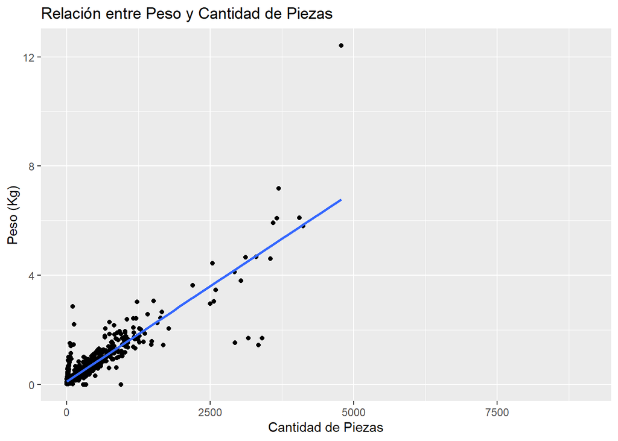

```r
ggplot(DT, aes(x = Pieces, y = Peso_Kg)) +
  geom_point() +  # Puntos de dispersión
  geom_smooth(method = "lm", se = FALSE) +  # Línea de regresión sin intervalo de confianza
  labs(title = "Relación entre Peso y Cantidad de Piezas",
       x = "Cantidad de Piezas",
       y = "Peso (Kg)")
```

Teniendo esto en cuenta, consideramos imputar los valores de Peso_Kg mediante una regresión lineal simple con Pieces siendo apropiado debido a la fuerte relación (p < 0.001, R-cuadrado ajustado de 0.787) entre ambas variables. Los coeficientes estimados revelan que el número de piezas influye significativamente en el peso de los conjuntos LEGO.

```r
#Filtrar las filas con valores faltantes en Peso_Kg
datos_faltantes <- DT[is.na(Peso_Kg), ]

# Imputar los valores faltantes de Peso_Kg usando las predicciones del modelo
DT[is.na(Peso_Kg), "Peso_Kg"] <- predict(modelo, newdata = datos_faltantes)
```

Y con la moda los factores:

```r
# Reemplazar "Age_NA" con NA en la variable Age
DT$Ages[DT$Ages == "Ages_NA"] <- NA
```

```r
# Definir la función moda para variables factor
moda_factor <- function(v) {
  # Convertir a vector de caracteres
  v <- as.character(v)

  # Contar la frecuencia de cada valor
  counts <- table(v)

  # Encontrar el valor con mayor frecuencia
  moda <- names(which.max(counts))

  # Devolver la moda
  moda
}

# Lista de nombres de columnas factor
columnas_factores <- c("Theme", "Ages", "Packaging", "Availability", "Size", "Year")

# Imputar la moda a los valores faltantes en las columnas factor
for (col in columnas_factores) {
  DT[[col]][is.na(DT[[col]])] <- moda_factor(DT[[col]])
}
```

Observamos que el factor “Ages” presenta demasiados niveles, lo que genera un exceso de información y dificulta nuestro análisis. Para simplificar el proceso y mejorar la gestión de los datos, consideramos recodificar este factor en un menor número de niveles.

```r
unique(DT$Ages)
```

```
##  [1] Ages_16+    Ages_7+     Ages_12+    Ages_18+    Ages_5 - 99 Ages_4 - 99
##  [7] Ages_4 - 7  Ages_4+     Ages_1 - 3  Ages_2 - 5  Ages_2+     Ages_1+
## [13] Ages_5+     Ages_6+     Ages_6 - 14 Ages_7 - 14 Ages_8+     Ages_10+
## [19] Ages_5 - 12 Ages_6 - 12 Ages_6 - 10 Ages_7 - 12 Ages_5 - 10 Ages_8 - 12
## [25] Ages_9 - 14 Ages_9+     Ages_9 - 12 Ages_8 - 14 Ages_11+    Ages_3+
## [31] Ages_3 - 6  Ages_2 - 6  Ages_4 - 6  Ages_14+
## 35 Levels: Ages_1 - 3 Ages_1+ Ages_10+ Ages_11+ Ages_12+ Ages_14+ ... Ages_NA
```

```r
#Recodificamos la variable Ages

DT$Ages <- fct_recode(
  DT$Ages,
  "1+" = "Ages_1 - 3",
  "1+" = "Ages_1+",
  "2+" = "Ages_2 - 5",
  "2+" = "Ages_2+",
  "2+" = "Ages_2 - 6",
  "3+" = "Ages_3 - 6",
  "3+" = "Ages_3+",
  "4+" = "Ages_4 - 99",
  "4+" = "Ages_4 - 7",
  "4+" = "Ages_4 - 6",
  "4+" = "Ages_4+",
  "5+" = "Ages_5 - 99",
  "5+" = "Ages_5 - 10",
  "5+" = "Ages_5 - 12",
  "5+" = "Ages_5+",
  "6+" = "Ages_6 - 14",
  "6+" = "Ages_6 - 10",
  "6+" = "Ages_6 - 12",
  "6+" = "Ages_6+",
  "7+" = "Ages_7 - 12",
  "7+" = "Ages_7 - 14",
  "7+" = "Ages_7+",
  "8+" = "Ages_8 - 14",
  "8+" = "Ages_8 - 12",
  "8+" = "Ages_8+",
  "9+" = "Ages_9 - 12",
  "9+" = "Ages_9 - 14",
  "9+" = "Ages_9+",
  "10+" = "Ages_10+",
  "11+" = "Ages_11+",
  "12+" = "Ages_12+",
  "14+" = "Ages_14+",
  "16+" = "Ages_16+",
  "18+" = "Ages_18+",
)
```

```r
unique(DT$Ages)
```

```
##  [1] 16+ 7+  12+ 18+ 5+  4+  1+  2+  6+  8+  10+ 9+  11+ 3+  14+
## Levels: 1+ 10+ 11+ 12+ 14+ 16+ 18+ 2+ 3+ 4+ 5+ 6+ 7+ 8+ 9+ Ages_NA
```

Tras realizar algunas transformaciones adicionales, hemos simplificado nuestros datos y los hemos vuelto más manejables. Además, hemos logrado eliminar la presencia de valores faltantes, lo que facilitará nuestro análisis y la interpretación de los resultados.

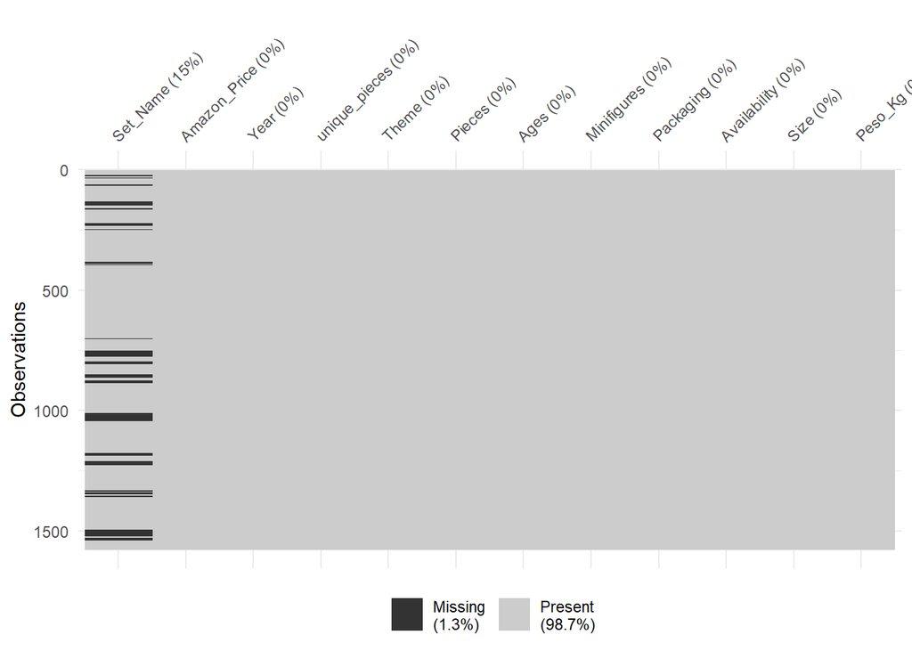

```r
# Crear el gráfico de mosaico de valores faltantes
vis_miss(DT)
```

Una vez disponemos de un data table completo y sin valores faltantes, a excepción de la variable “Set_Name” que es de tipo caracter y representa el nombre de cada juego, no tiene sentido imputar valores a esta variable ya que no aporta más información relevante que el propio nombre del juego.

Hemos observado que algunas variables, como el peso del juego y el número de piezas, están relacionadas entre sí. Ahora, procederemos a analizar cómo se relacionan entre sí las variables de nuestro conjunto de datos.

```r
colnames(DT)
```

```
##  [1] "Set_Name"      "Amazon_Price"  "Year"          "unique_pieces"
##  [5] "Theme"         "Pieces"        "Ages"          "Minifigures"
##  [9] "Packaging"     "Availability"  "Size"          "Peso_Kg"
```

```r
# Análisis exploratorio de datos
summary_DT <- DT[, summary(.SD), .SDcols = c("Amazon_Price", "Year", "Theme", "unique_pieces", "Pieces", "Minifigures", "Ages", "Peso_Kg", "Size", "Packaging", "Availability")]
print(summary_DT)
```

```
##   Amazon_Price      Year            Theme     unique_pieces        Pieces
##  Min.   :  2.74   2018:448   Star Wars :370   Min.   :   1.0   Min.   :   1.0
##  1st Qu.: 14.02   2019:427   City      :120   1st Qu.:  39.0   1st Qu.:  73.0
##  Median : 22.95   2020:702   Friends   :112   Median :  83.0   Median : 192.0
##  Mean   : 31.88              Ninjago   : 90   Mean   : 118.7   Mean   : 396.2
##  3rd Qu.: 43.98              Duplo     : 71   3rd Qu.: 163.0   3rd Qu.: 447.0
##  Max.   :131.95              BrickHeadz: 67   Max.   :1067.0   Max.   :9036.0
##                              (Other)   :747
##   Minifigures          Ages        Peso_Kg           Size
##  Min.   : 1.000   7+     :778   Min.   : 0.0000   Large:  71
##  1st Qu.: 1.000   6+     :198   1st Qu.: 0.1905   Small:1506
##  Median : 2.000   8+     :137   Median : 0.3600
##  Mean   : 2.937   5+     :125   Mean   : 0.6607
##  3rd Qu.: 4.000   10+    : 95   3rd Qu.: 0.7500
##  Max.   :28.000   4+     : 72   Max.   :12.7098
##                   (Other):172
##             Packaging                Availability
##  Box             :1335   Educational       :  18
##  Polybag         : 169   LEGO exclusive    : 168
##  Foil pack       :  22   LEGOLAND exclusive:   6
##  Plastic box     :  13   Not sold          :  28
##  Blister pack    :   9   Promotional       :  18
##  Plastic canister:   9   Retail            :1236
##  (Other)         :  20   Retail - limited  : 103
```

El resumen muestra la variabilidad en precios de Amazon y la distribución de años y temas. Además, se destaca la diversidad en la cantidad de piezas y minifiguras, así como en las edades recomendadas. Por último, se observa la amplitud en el peso de los juegos y la diversidad de embalajes y disponibilidad en el mercado.

Visualicemos la distribución de las distintas variables.

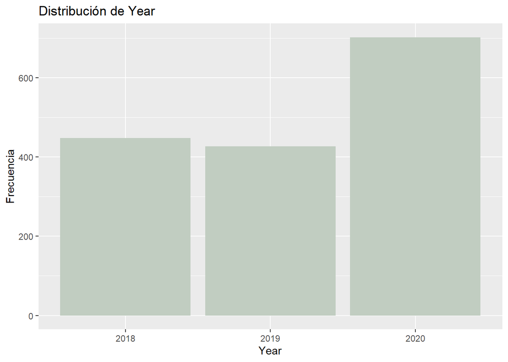

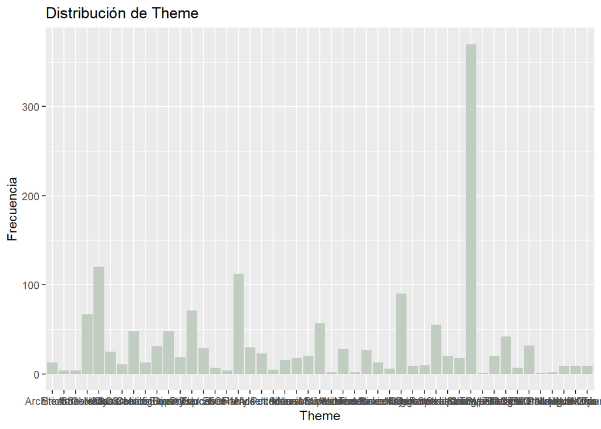

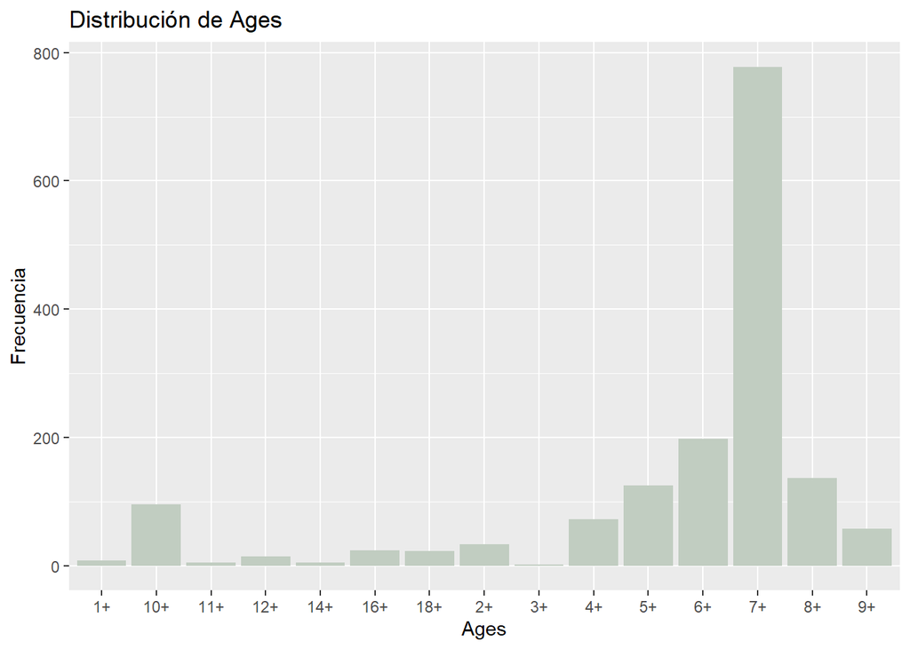

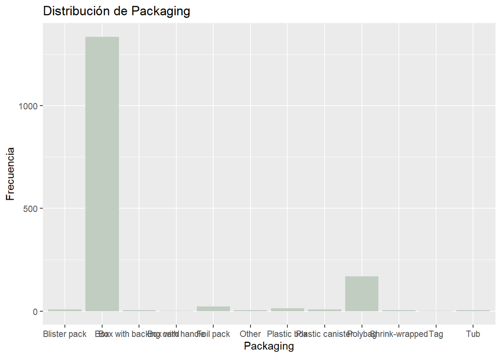

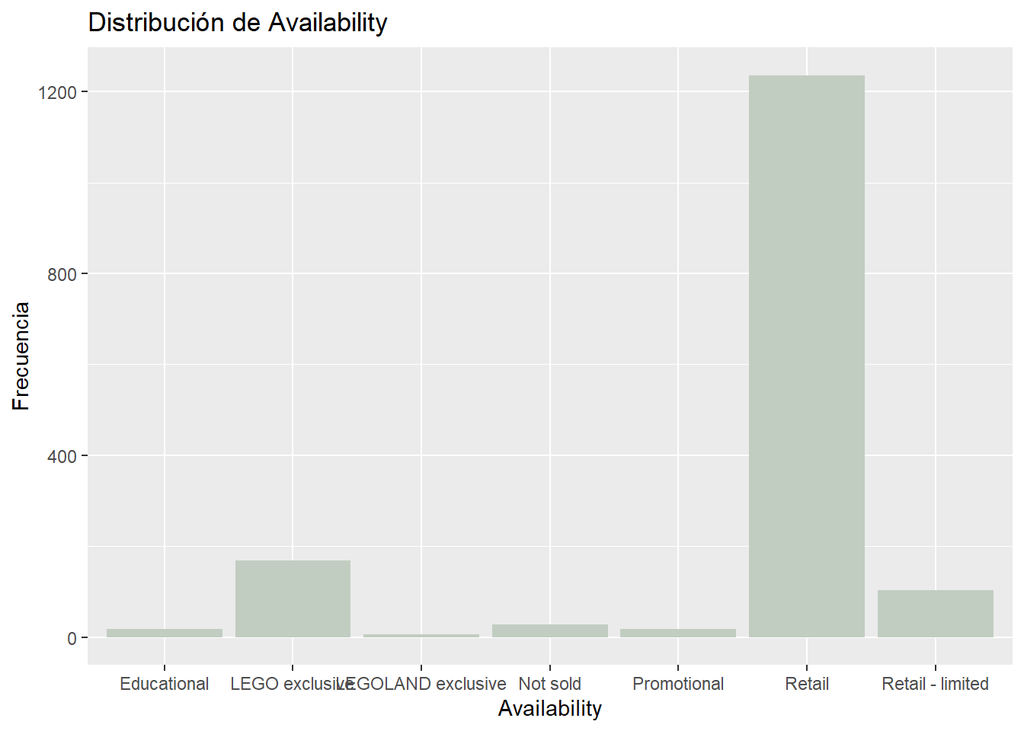

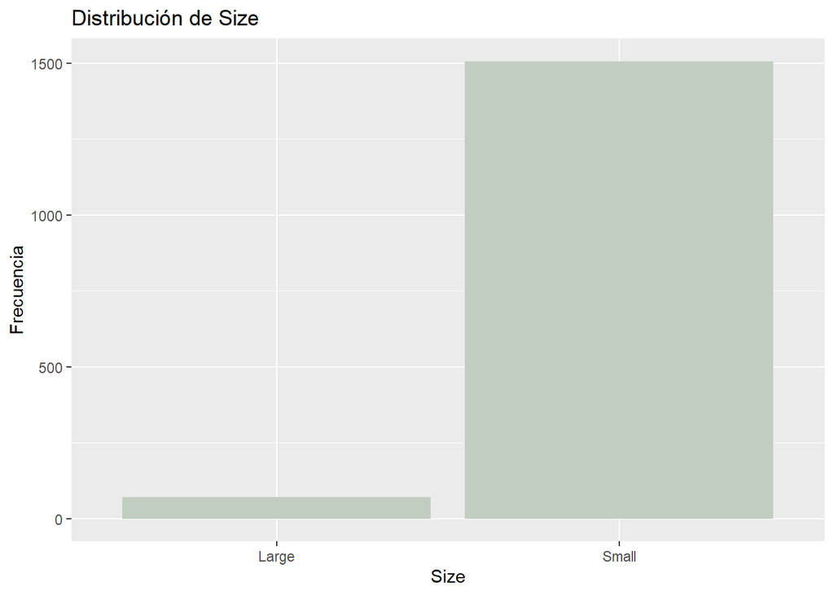

```r
# Seleccionar variables categóricas
variables_categoricas <- c("Year", "Theme", "Ages", "Packaging", "Availability", "Size")

# Visualizar cada variable
lapply(variables_categoricas, function(variable) {
  ggplot(DT, aes_string(x = variable)) +
    geom_bar(stat = "count", fill = "honeydew3") +
    labs(title = paste0("Distribución de ", variable), x = variable, y = "Frecuencia")
})
```

Observamos que hay una variable que destaca notablemente sobre las demás en las visualizaciones. Es importante considerar que este resaltado puede estar influenciado por la imputación por la moda que llevamos a cabo anteriormente.

Para la visualización de las variables numéricas realizaremos un gráfico de denisdad, similar al histograma, pero muestra la densidad de probabilidad de la variable. Nos permite una visualización más suave de la distribución y facilita la comparación de variables con diferentes escalas

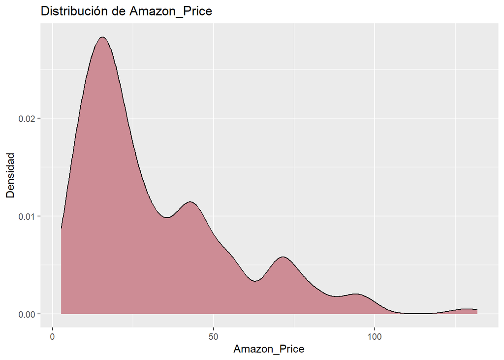

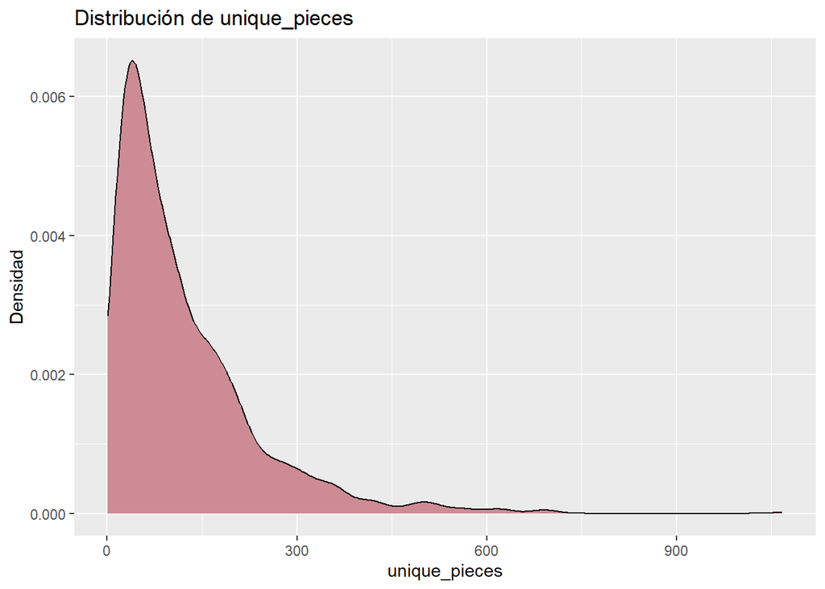

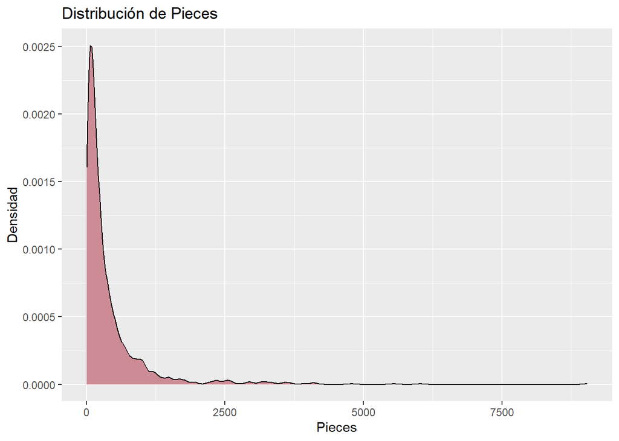

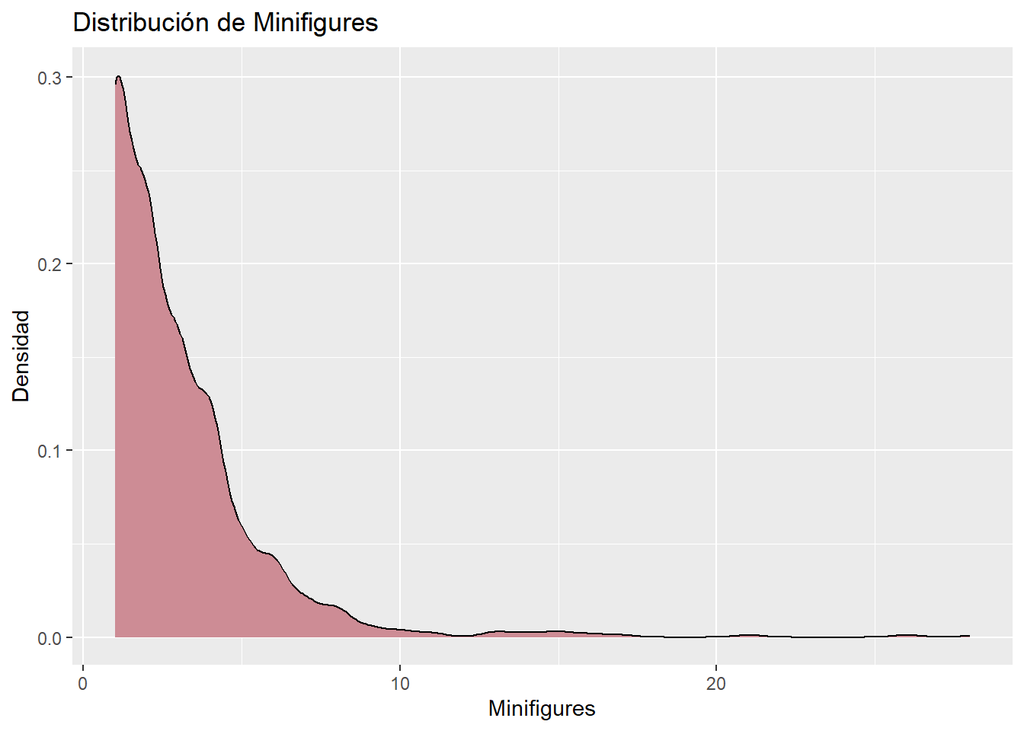

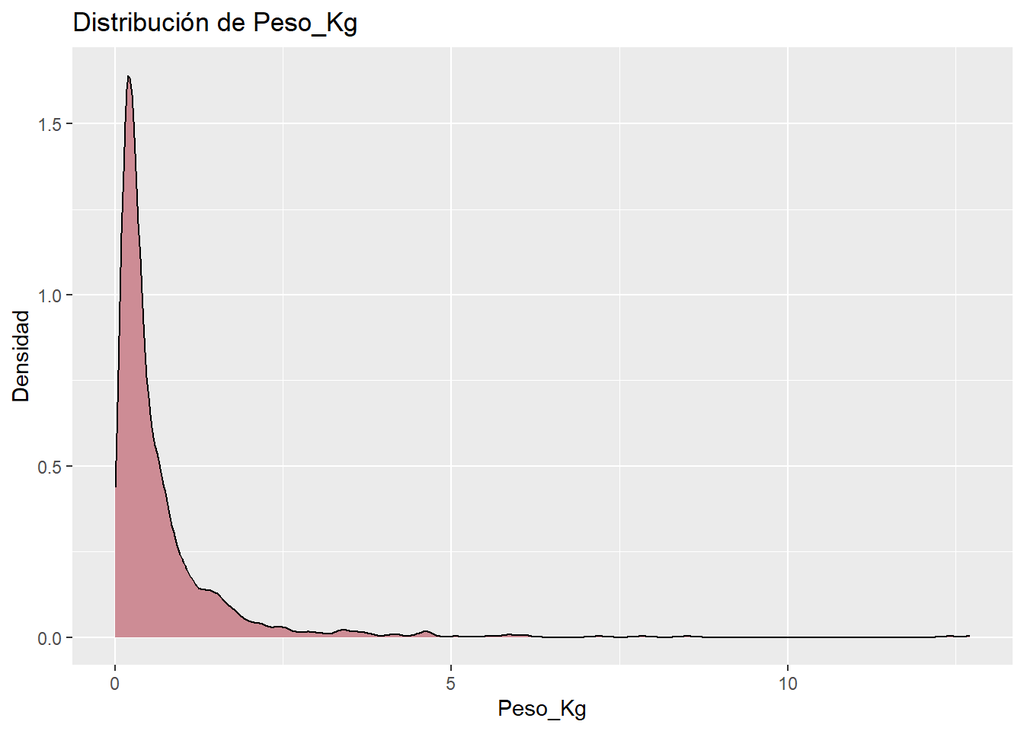

```r
# Seleccionar variables numéricas
variables_numericas <- names(DT)[sapply(DT, is.numeric)]

# Generar un gráfico de densidad para cada variable
lapply(variables_numericas, function(variable) {
  ggplot(DT, aes_string(x = variable)) +
    geom_density(fill = "lightpink3") +
    labs(title = paste0("Distribución de ", variable), x = variable, y = "Densidad")
})
```

Observamos la presencia de una “cola” en las distintas visualizaciones, lo cual sugiere la posible presencia de valores atípicos o outliers en los datos.

A continuación veremos como se relacionan las diferentes variables númericas entre ellas.

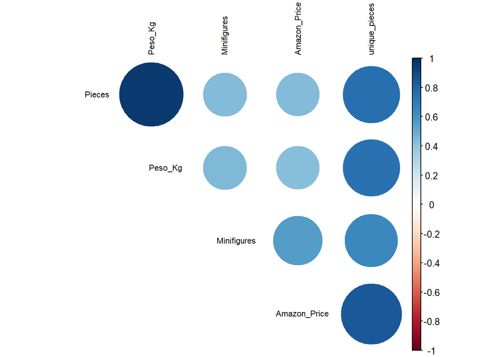

```r
data_num <- select_if(DT, (is.numeric)) # nos quedamos con todas las variables numéricas

correlacion_pearson_data = cor(data_num, use = "pairwise.complete.obs")

corrplot(correlacion_pearson_data,method = "circle", type="upper", addgrid.col = NA, tl.col = "black", diag = FALSE, order = "hclust", tl.cex=0.7) # visualización de la matriz
```

```r
print(correlacion_pearson_data)
```

```
##               Amazon_Price unique_pieces    Pieces Minifigures   Peso_Kg
## Amazon_Price     1.0000000     0.8497539 0.4334439   0.5570897 0.4279195
## unique_pieces    0.8497539     1.0000000 0.7521095   0.6414598 0.7453478
## Pieces           0.4334439     0.7521095 1.0000000   0.4399791 0.9523391
## Minifigures      0.5570897     0.6414598 0.4399791   1.0000000 0.4411522
## Peso_Kg          0.4279195     0.7453478 0.9523391   0.4411522 1.0000000
```

A continuación, veremos como se relacionan las variables categóricas con el precio en amazon de cada juego.

```r
data_fact <- select_if(DT, (is.factor))
colnames(data_fact)
```

```
## [1] "Year"         "Theme"        "Ages"         "Packaging"    "Availability"
## [6] "Size"
```

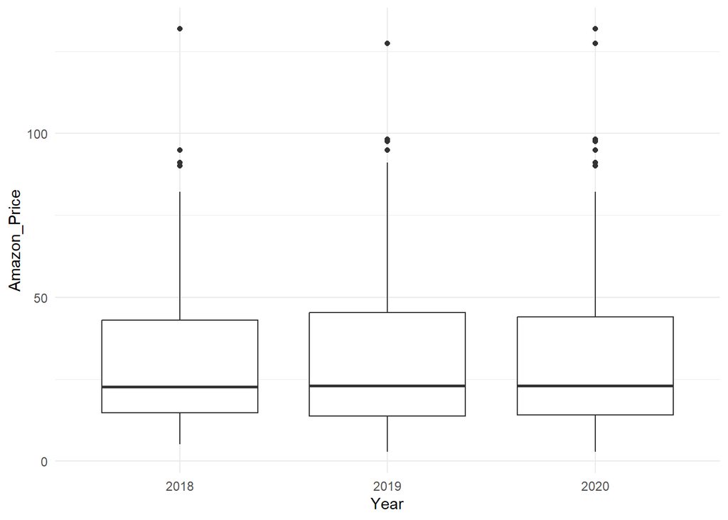

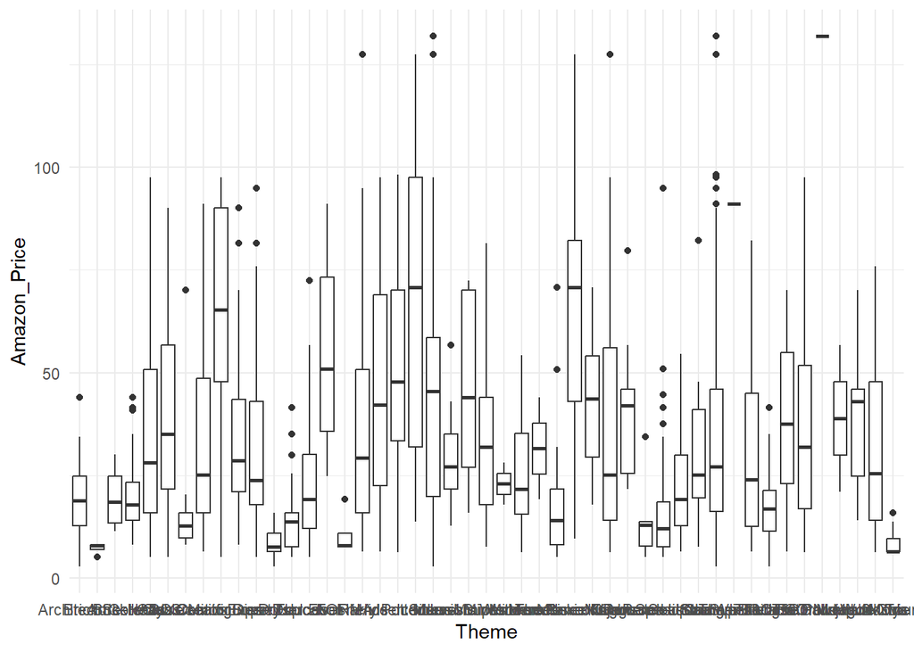

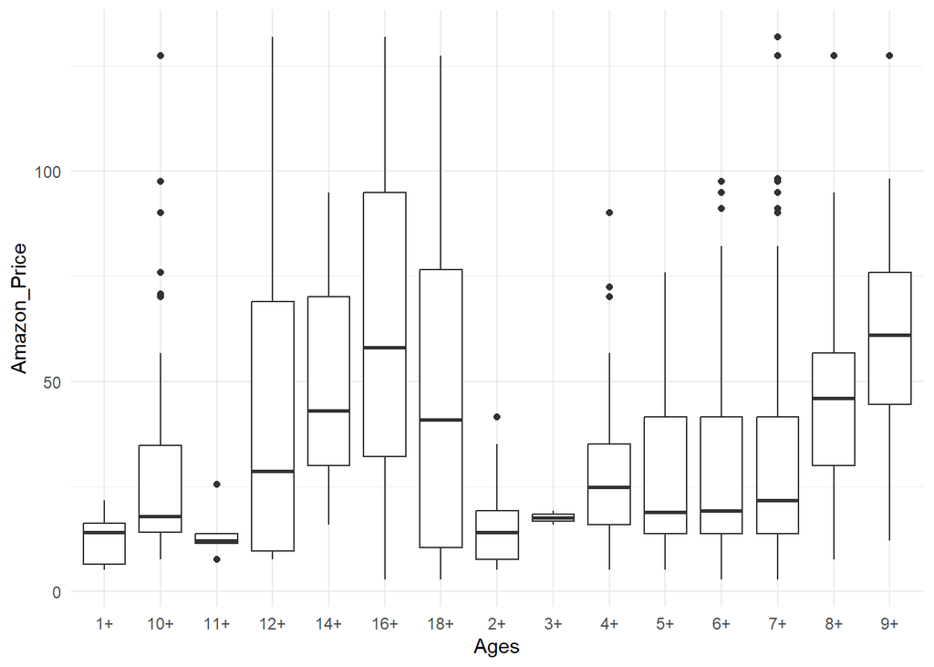

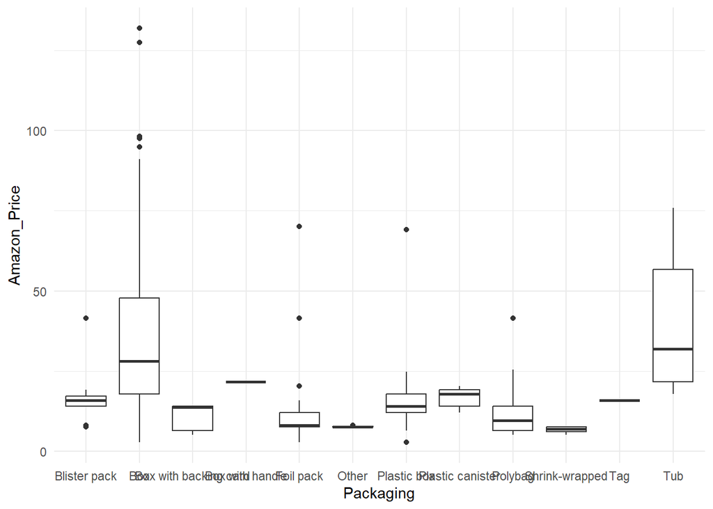

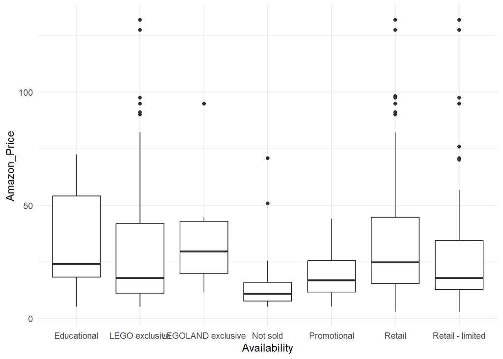

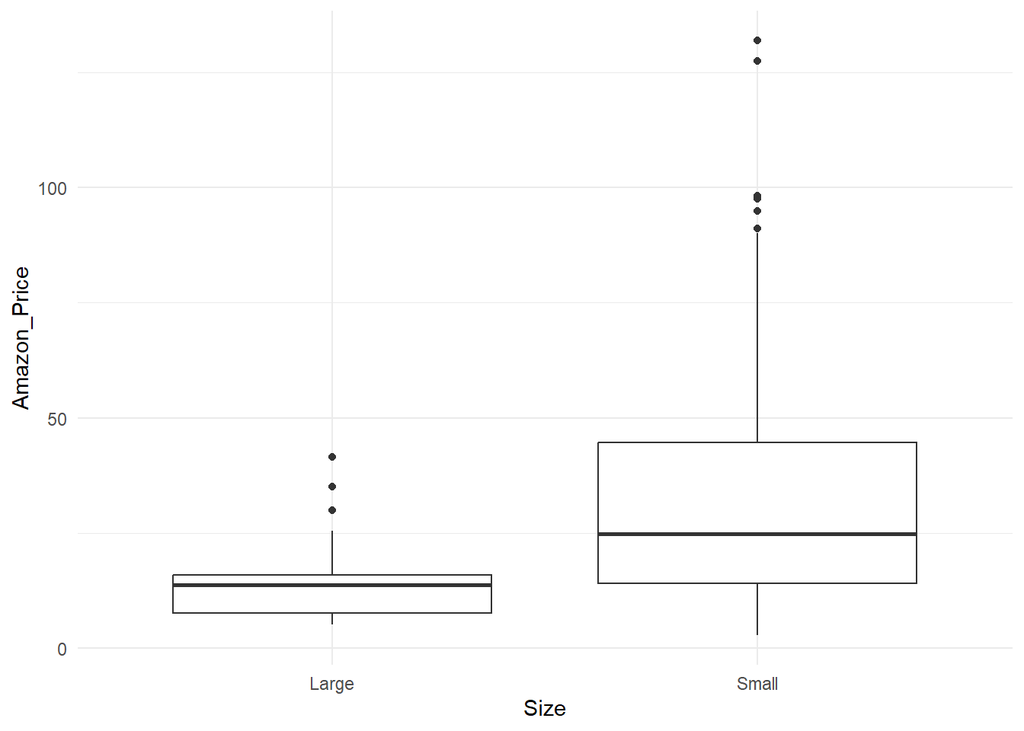

```r
data_fact <- select_if(DT, (is.factor))

# Obtener nombres de las variables categóricas
categorias <- names(data_fact)

# Crear una lista para almacenar los gráficos
plots <- list()

# Iterar sobre cada variable categórica
for (categoria in categorias) {
  # Crear un gráfico de caja para cada variable categórica
  plot <- ggplot(data = DT, aes_string(x = categoria, y = "Amazon_Price")) +
    geom_boxplot() +
    labs(x = categoria, y = "Amazon_Price") +
    theme_minimal()

# Almacenar el gráfico en la lista
  plots[[categoria]] <- plot
}

# Mostrar los gráficos
plots
```

```r
DT %>%
  filter(Ages == "18+") %>%
  arrange(desc(Amazon_Price)) %>%
  head()
```

```
##                         Set_Name Amazon_Price Year unique_pieces       Theme
## 1:                Elf Club House       127.48 2020           377       Icons
## 2:             123 Sesame Street       127.48 2020           610       Ideas
## 3:           Ghostbusters ECTO-1        97.53 2020           569       Icons
## 4:            Mos Eisley Cantina        97.53 2020           632   Star Wars
## 5: Mickey Mouse and Minnie Mouse        94.98 2020           421      Disney
## 6: Nintendo Entertainment System        82.23 2020           516 Super Mario
##    Pieces Ages Minifigures Packaging     Availability  Size  Peso_Kg
## 1:   1197  18+           4       Box   LEGO exclusive Small 1.320000
## 2:   1367  18+           6       Box Retail - limited Small 1.860000
## 3:   2352  18+           8       Box   LEGO exclusive Small 3.388299
## 4:   3187  18+          21       Box   LEGO exclusive Small 4.552784
## 5:   1739  18+           9       Box   LEGO exclusive Small 2.533414
## 6:   2646  18+           1       Box   LEGO exclusive Small 3.798309
```

```r
DT %>%
  filter(Ages == "1+") %>%
  arrange(desc(Amazon_Price)) %>%
  head()
```

```
##             Set_Name Amazon_Price Year unique_pieces Theme Pieces Ages
## 1:  Deluxe Brick Box        21.67 2020            58 Duplo     85   1+
## 2:    Alphabet Truck        17.21 2020            35 Duplo     36   1+
## 3:         Heart Box        15.93 2020            39 Duplo     80   1+
## 4:         Brick Box        15.93 2020            46 Duplo     65   1+
## 5: My First Ladybird        12.11 2018             5 Duplo      6   1+
## 6: My First Race Car         6.37 2018             6 Duplo      6   1+
##    Minifigures Packaging Availability  Size  Peso_Kg
## 1:           2       Tub       Retail Large 1.420000
## 2:           2       Box       Retail Large 0.850000
## 3:           2       Box       Retail Large 0.940000
## 4:           2       Tag       Retail Large 1.010000
## 5:           1       Box       Retail Large 0.116586
## 6:           1       Box       Retail Large 0.130000
```

## 1.2 Analisis por temática y cantidad de minifiguras

Dada la información previa, con el objetivo de realizar una segmentación del mercado basada en temáticas, es fundamental comenzar por visualizar la frecuencia de cada temática presente en nuestros datos. Este enfoque nos permitirá comprender la distribución de las temáticas y su relevancia en nuestro conjunto de datos, facilitando así la identificación de patrones y la posterior segmentación del mercado de manera más informada y precisa.

```r
tema_freq <- unique(DT[ , .(.N), by = Theme])
# Ordenamos
setorder(tema_freq, -N)

print(head(tema_freq, 6))
```

```
##         Theme   N
## 1:  Star Wars 370
## 2:       City 120
## 3:    Friends 112
## 4:    Ninjago  90
## 5:      Duplo  71
## 6: BrickHeadz  67
```

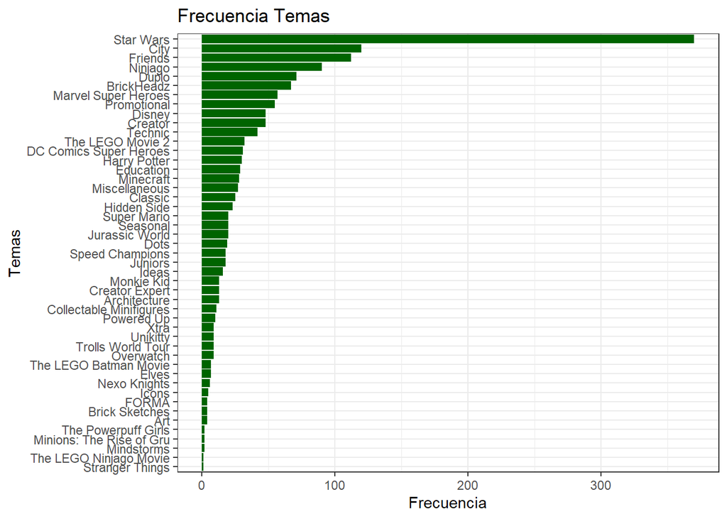

```r
ggplot(tema_freq, aes( x = fct_reorder(Theme, N), y = N)) +
  geom_col(group = 1, fill = 'darkgreen') +
  coord_flip() +
  labs(x = 'Temas', y = 'Frecuencia', title = 'Frecuencia Temas') +
  theme_bw()
```

Vemos como la temática de Star Wars es el que con diferencia tiene una mayor frecuencia.

```r
# Filtrar para eliminar las observaciones con valores faltantes en Minifigures y Theme
DT_filtrados <- DT[complete.cases(DT$Minifigures) & complete.cases(DT$Theme), ]

# Calcular la suma de Minifigures por tema y ordenar de manera descendente
temas_figuras <- DT_filtrados[, .(Suma_Minifiguras = sum(Minifigures)), by = Theme][order(-Suma_Minifiguras)][1:10]

# Visualizar los 10 temas más freceuntes junto con la cantidad de minifiguras
print(temas_figuras)
```

```
##                   Theme Suma_Minifiguras
##  1:           Star Wars             1237
##  2:                City              429
##  3:             Ninjago              279
##  4:             Friends              202
##  5: Marvel Super Heroes              188
##  6:        Harry Potter              171
##  7:          BrickHeadz              165
##  8:               Duplo              140
##  9:              Disney              115
## 10:             Technic              113
```

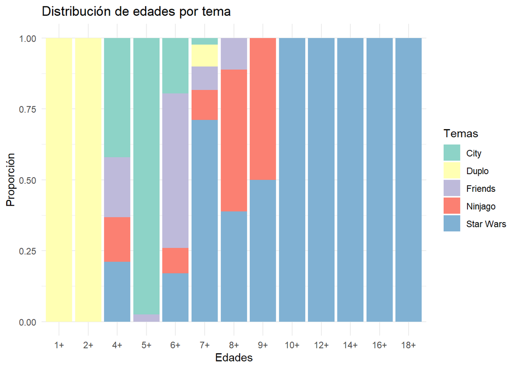

```r
# Especificar el orden deseado de las edades
orden_edades <- c("1+", "2+", "3+", "4+", "5+",
                  "6+", "7+", "8+", "9+", "10+",
                  "11+", "12+", "14+", "16+", "18+")

# Convertir la variable de edades en un factor con el orden deseado
DT$Ages <- factor(DT$Ages, levels = orden_edades)

# Filtrar para obtener las cinco principales temáticas
top_themes <- DT[, .N, by = Theme][order(-N)][1:5]$Theme

# Filtrar el dataset para incluir solo las observaciones de las cinco principales temáticas
DT_top <- DT[Theme %in% top_themes]

# Crear el gráfico de mosaico
ggplot(DT_top, aes(x = Ages, fill = Theme)) +
  geom_bar(position = "fill") +
  scale_fill_brewer(palette = "Set3") +
  theme_minimal() +
  labs(x = "Edades", y = "Proporción", fill = "Temas") +
  ggtitle("Distribución de edades por tema")
```

Podemos ver la distribución de los Temas por EDAD, viendo como para los niños “mayores” y adolescentes va destinado la temática de Star Wars, que a su vez es la mayoritaria, mientras que para los más pequeños está destinado Duplo, analicemos las diferencias entre ambos.

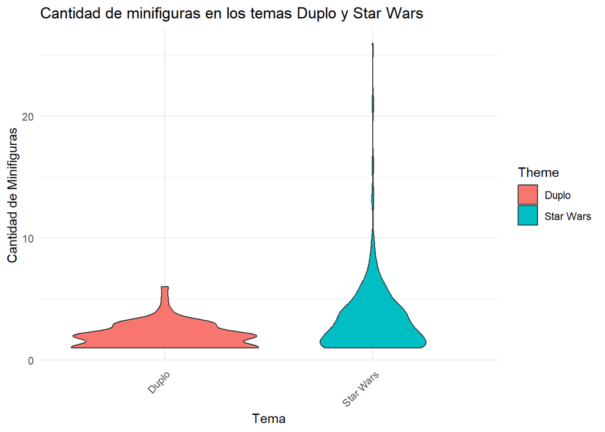

```r
# Filtrar el dataset para incluir solo los temas Duplo y Star Wars
DT_duplo_starwars <- DT[DT$Theme %in% c("Duplo", "Star Wars"), ]

# Crear el gráfico de violín
ggplot(DT_duplo_starwars, aes(x = Theme, y = Minifigures, fill = Theme)) +
  geom_violin() +
  labs(title = "Cantidad de minifiguras en los temas Duplo y Star Wars",
       x = "Tema",
       y = "Cantidad de Minifiguras") +
  theme_minimal() +
  theme(axis.text.x = element_text(angle = 45, hjust = 1))
```

La temática Star Wars generalmente tienen más minifiguras que los de la temática Duplo. La cantidad de minifiguras en Star Wars tiene una mayor dispersión, con algunos sets que tienen un número significativamente mayor de minifiguras que otros. Veamos si la cantidad de minifiguras está relacionado con el precio en Amazon y la edad

Star Wars

```r
DT_top5_mas <- DT %>%
  filter(Theme %in% c("Star Wars")) %>%
  arrange(desc(Minifigures)) %>%
  slice(1:5) %>%
  select(Theme, Minifigures, Amazon_Price, Ages)

DT_top5_menos <- DT %>%
  filter(Theme %in% c("Star Wars")) %>%
  arrange(Minifigures) %>%
  slice(1:5) %>%
  select(Theme, Minifigures, Amazon_Price, Ages)

print(DT_top5_mas)
```

```
##        Theme Minifigures Amazon_Price Ages
## 1: Star Wars          26        17.87   7+
## 2: Star Wars          21        94.98  14+
## 3: Star Wars          21        97.53  18+
## 4: Star Wars          16        28.04   7+
## 5: Star Wars          16        43.98   7+
```

```r
print(DT_top5_menos)
```

```
##        Theme Minifigures Amazon_Price Ages
## 1: Star Wars           1        14.02   7+
## 2: Star Wars           1         9.56   7+
## 3: Star Wars           1        13.77   7+
## 4: Star Wars           1         7.65   7+
## 5: Star Wars           1         6.37   7+
```

Duplo

```r
DT_top5_mas <- DT %>%
  filter(Theme %in% c("Duplo")) %>%
  arrange(desc(Minifigures)) %>%
  slice(1:5) %>%
  select(Theme, Minifigures, Amazon_Price, Ages)

DT_top5_menos <- DT %>%
  filter(Theme %in% c("Duplo")) %>%
  arrange(Minifigures) %>%
  slice(1:5) %>%
  select(Theme, Minifigures, Amazon_Price, Ages)

print(DT_top5_mas)
```

```
##    Theme Minifigures Amazon_Price Ages
## 1: Duplo           6        19.12   2+
## 2: Duplo           5        29.96   2+
## 3: Duplo           4         6.37   7+
## 4: Duplo           4         7.65   7+
## 5: Duplo           3         7.65   7+
```

```r
print(DT_top5_menos)
```

```
##    Theme Minifigures Amazon_Price Ages
## 1: Duplo           1         7.65   7+
## 2: Duplo           1        12.11   1+
## 3: Duplo           1         6.37   1+
## 4: Duplo           1         6.30   7+
## 5: Duplo           1         9.56   7+
```

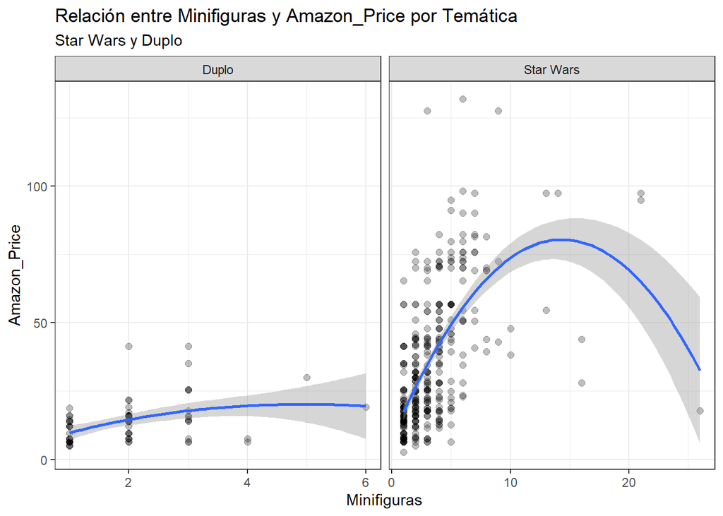

```r
# Filtrar el dataset para incluir solo las temáticas de Star Wars y Duplo
DT_filtered <- DT[Theme %in% c("Star Wars", "Duplo")]

# Crear el gráfico de dispersión
starwars_duplo_gr <- ggplot(DT_filtered, aes(x = Minifigures, y = Amazon_Price)) +
  geom_point(fill = 'grey', alpha = 0.25, size = 2) +
  geom_smooth(span = 2) +
  facet_grid(. ~ Theme, scales = 'free') +
  labs(x = 'Minifiguras', y = 'Amazon_Price') +
  theme_bw()

# Agregar títulos y subtítulos
starwars_duplo_gr +
  ggtitle("Relación entre Minifiguras y Amazon_Price por Temática") +
  labs(subtitle = "Star Wars y Duplo")
```

En el caso de Star Wars, si vemos de forma más clara que en Duplo, cierta relación positiva entre el precio en Amazon del lego y la cantidad de Minifiguras que contiene este.

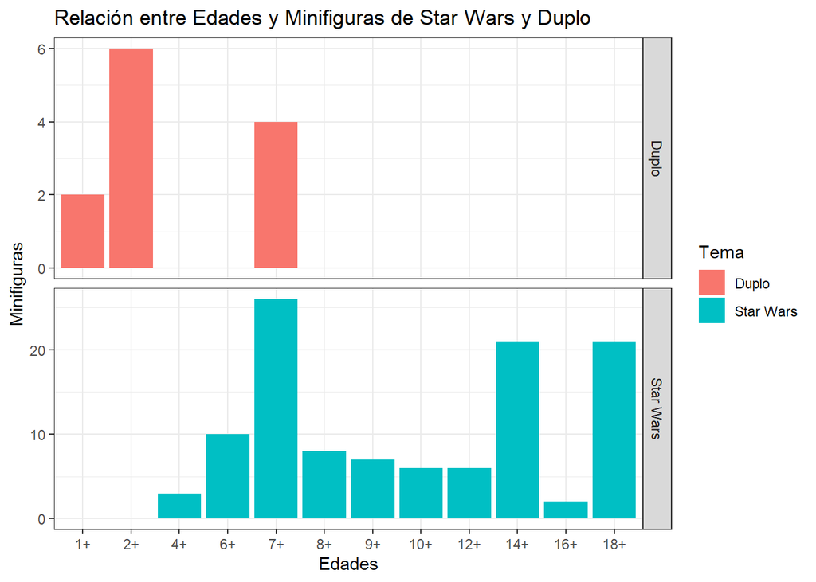

```r
DT$Ages <- factor(DT$Ages, levels = c("1+", "2+", "3+", "4+", "5+", "6+", "7+", "8+", "9+", "10+",
                                      "11+", "12+", "14+", "16+", "18+"))

# Filtrar el dataset para incluir solo los temas Star Wars y Duplo
temas_seleccionados <- c("Star Wars", "Duplo")
DT_filtrado <- DT[Theme %in% temas_seleccionados]

# Crear el gráfico de barras
grafico <- ggplot(DT_filtrado, aes(x = Ages, y = Minifigures, fill = Theme)) +
  geom_bar(stat = "identity", position = "dodge") +  # Adjust bar positioning
  facet_grid(Theme ~ ., scales = "free") +
  labs(x = "Edades", y = "Minifiguras", fill = "Tema") +
  theme_bw()

# Añadir título y subtítulo
grafico +
  labs(title = "Relación entre Edades y Minifiguras de Star Wars y Duplo")
```

No parece haber ningún patrón claro de que la cantidad de minifiguras que contiene influya en la edad recomendada.

Con base en el análisis realizado, se observa una clara diferenciación en las temáticas entre Duplo y Star Wars, reflejada en la distribución de edades recomendadas y la cantidad de minifiguras. Duplo tiende a estar dirigido a un público más joven, mientras que Star Wars a un público más mayor, lo que sugiere una segmentación de mercado por parte de la marca LEGO. Sin embargo, se nota una variedad en la cantidad de minifiguras dentro de cada temática, sin una correlación evidente con las edades recomendadas, aunque se aprecia una relación con los precios en Amazon. Este análisis inicial proporciona una visión general de las estrategias de precios, lo que podría guiar decisiones futuras en marketing y desarrollo de productos.

Continuando con está línea del análisis, veremos la relación entre la complejidad del juego (cantidad de piezas) con la cantidad de minifiguras, el precio en Amazon y el peso.

## 1.3 Analisis por complejidad

Continuando con esta línea de análisis, exploraremos la relación entre la complejidad del juego, medida por la cantidad de piezas, y la cantidad de minifiguras, el precio en Amazon y el peso. En primer lugar, nos enfocaremos en la temática de Star Wars para comprender cómo la complejidad de los juegos influye en estas variables clave, y, a continuación lo haremos con Duplo.

Star Wars

```r
SW_mas_complejos <- DT %>%
  filter(Theme %in% c("Star Wars")) %>%
  arrange(desc(Pieces)) %>%
  slice(1:5) %>%
  select(Set_Name, Theme, Pieces, Minifigures, Amazon_Price, Peso_Kg)

SW_menos_complejos <- DT %>%
  filter(Theme %in% c("Star Wars")) %>%
  arrange(Pieces) %>%
  slice(1:5) %>%
  select(Set_Name, Theme, Pieces, Minifigures, Amazon_Price, Peso_Kg)
print(SW_mas_complejos)
```

```
##                   Set_Name     Theme Pieces Minifigures Amazon_Price   Peso_Kg
## 1: Imperial Star Destroyer Star Wars   4784           2         8.15 12.420000
## 2:                    <NA> Star Wars   3553           5        91.15  5.063204
## 3:                    <NA> Star Wars   3306           6        98.16  4.718740
## 4:      Mos Eisley Cantina Star Wars   3187          21        97.53  4.552784
## 5:                    <NA> Star Wars   2933           1        13.77  4.198557
```

```r
print(SW_menos_complejos)
```

```
##    Set_Name     Theme Pieces Minifigures Amazon_Price   Peso_Kg
## 1:     <NA> Star Wars      1           2        35.06 0.1096130
## 2:     <NA> Star Wars      1           2         5.10 0.1096130
## 3:     <NA> Star Wars      1           1        25.43 0.1096130
## 4:     <NA> Star Wars      1           1        20.39 0.1096130
## 5:     <NA> Star Wars      5           1        21.67 0.1151914
```

Duplo

```r
D_mas_complejos <- DT %>%
  filter(Theme %in% c("Duplo")) %>%
  arrange(desc(Pieces)) %>%
  slice(1:5) %>%
  select(Set_Name, Theme, Pieces, Minifigures, Amazon_Price, Peso_Kg)

D_menos_complejos <- DT %>%
  filter(Theme %in% c("Duplo")) %>%
  arrange(Pieces) %>%
  slice(1:5) %>%
  select(Set_Name, Theme, Pieces, Minifigures, Amazon_Price, Peso_Kg)

print(D_mas_complejos)
```

```
##                      Set_Name Theme Pieces Minifigures Amazon_Price   Peso_Kg
## 1:           Creative Animals Duplo    175           3        25.50 0.3522721
## 2:          Modular Playhouse Duplo    129           3        17.85 2.2000000
## 3: Tower Crane & Construction Duplo    123           5        29.96 0.2797533
## 4:              World Animals Duplo    121           6        19.12 0.2769641
## 5:               Creative Fun Duplo    120           1        18.87 1.4500000
```

```r
print(D_menos_complejos)
```

```
##             Set_Name Theme Pieces Minifigures Amazon_Price   Peso_Kg
## 1:  My First Giraffe Duplo      5           1        12.11 0.1151914
## 2: My First Ladybird Duplo      6           1        12.11 0.1165860
## 3: My First Race Car Duplo      6           1         6.37 0.1300000
## 4:        Fire Truck Duplo      6           1         5.10 0.1500000
## 5:     My First Duck Duplo      6           1        12.11 0.1165860
```

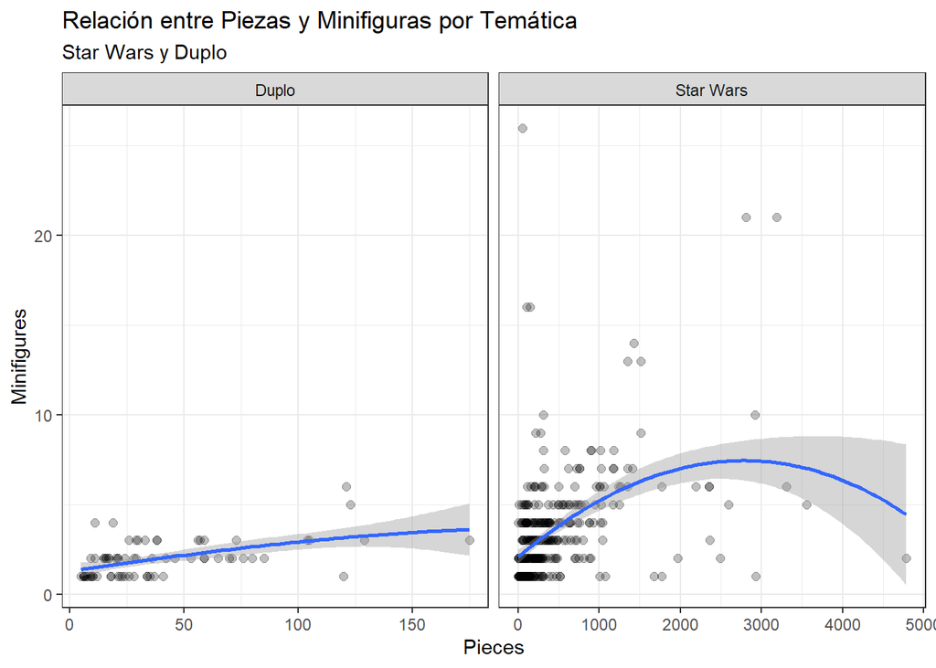

```r
# Filtrar el dataset para incluir solo las temáticas de Star Wars y Duplo
DT_filtered <- DT[Theme %in% c("Star Wars", "Duplo")]

# Crear el gráfico
starwars_duplo_gr <- ggplot(DT_filtered, aes(x = Pieces, y = Minifigures)) +
  geom_point(fill = 'grey', alpha = 0.25, size = 2) +
  geom_smooth(span = 2) +
  facet_grid(. ~ Theme, scales = 'free') +
  labs(x = 'Pieces', y = 'Minifigures') +
  theme_bw()

# Agregar títulos y subtítulos
starwars_duplo_gr +
  ggtitle("Relación entre Piezas y Minifiguras por Temática") +
  labs(subtitle = "Star Wars y Duplo")
```

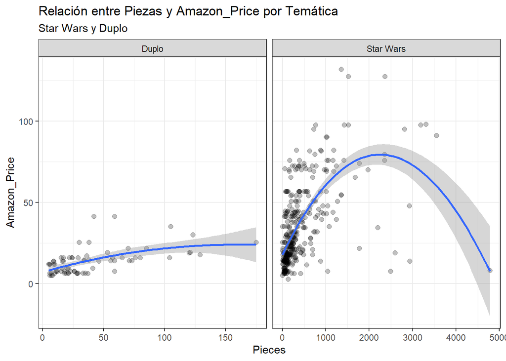

```r
# Filtrar el dataset para incluir solo las temáticas de Star Wars y Duplo
DT_filtered <- DT[Theme %in% c("Star Wars", "Duplo")]

# Crear el gráfico
starwars_duplo_gr <- ggplot(DT_filtered, aes(x = Pieces, y = Amazon_Price)) +
  geom_point(fill = 'grey', alpha = 0.25, size = 2) +
  geom_smooth(span = 2) +
  facet_grid(. ~ Theme, scales = 'free') +
  labs(x = 'Pieces', y = 'Amazon_Price') +
  theme_bw()

# Agregar títulos y subtítulos
starwars_duplo_gr +
  ggtitle("Relación entre Piezas y Amazon_Price por Temática") +
  labs(subtitle = "Star Wars y Duplo")
```

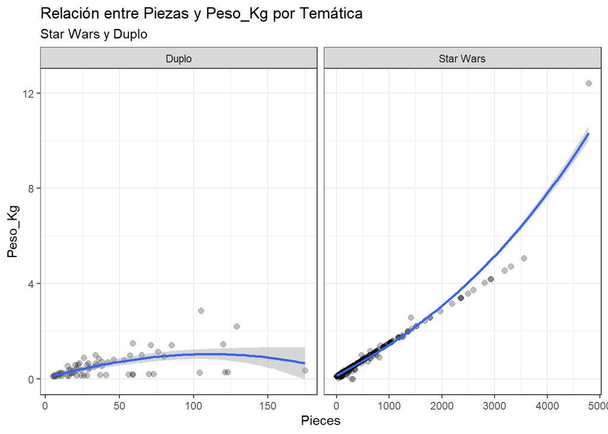

```r
# Filtrar el dataset para incluir solo las temáticas de Star Wars y Duplo
DT_filtered <- DT[Theme %in% c("Star Wars", "Duplo")]

# Crear el gráfico
starwars_duplo_gr <- ggplot(DT_filtered, aes(x = Pieces, y = Peso_Kg)) +
  geom_point(fill = 'grey', alpha = 0.25, size = 2) +
  geom_smooth(span = 2) +
  facet_grid(. ~ Theme, scales = 'free') +
  labs(x = 'Pieces', y = 'Peso_Kg') +
  theme_bw()

# Agregar títulos y subtítulos
starwars_duplo_gr +
  ggtitle("Relación entre Piezas y Peso_Kg por Temática") +
  labs(subtitle = "Star Wars y Duplo")
```

Según la observación de los gráficos, se evidencia una relación positiva entre la complejidad del juego, medida por el número de piezas, y otras variables analizadas. Esta relación parece ser más notable con el peso del producto y el precio en Amazon, en comparación con la cantidad de minifiguras. Sin embargo, se identifican ciertos matices en esta relación.

## 1.4 Clusterización

```r
seleccion <- DT %>%
  filter(Theme %in% c("Star Wars", "Duplo")) %>%
  select(Theme, Pieces, Ages, Minifigures, Amazon_Price)
```

```r
library(mclust)
# Ajustar el modelo GMM
gmm_model <- Mclust(seleccion[, -1])

# Asignar cada punto a un cluster
seleccion$cluster <- gmm_model$classification
```

```r
n_clusters <- seq(2, 10)
models <- lapply(n_clusters, function(k) Mclust(seleccion[, -1], G = k))
bics <- sapply(models, function(model) BIC(model))

# Seleccionar el modelo con el BIC más bajo
best_model <- models[[which.min(bics)]]
```

El análisis de clustering nos ha permitido identificar patrones y agrupar los juegos de LEGO de las temáticas “Star Wars” y “Duplo” en función de sus características, como el número de piezas y el precio en Amazon. Los clusters obtenidos nos proporcionan información sobre cómo se relacionan estas variables entre sí y cómo se distribuyen los juegos dentro de cada cluster.

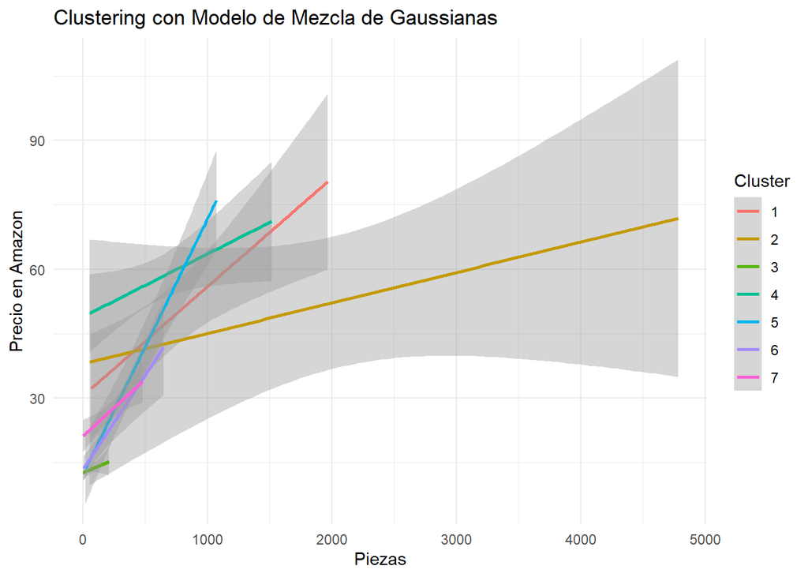

```r
# Asegúrate de que tienes el objeto cluster correctamente asignado a tu conjunto de datos seleccion
seleccion <- seleccion %>%
  mutate(cluster = gmm_model$classification)

# Graficar los puntos coloreados por cluster
ggplot(seleccion, aes(x = Pieces, y = Amazon_Price, color = factor(cluster))) +
  geom_smooth(method = "lm", aes(color = factor(cluster))) +
  labs(title = "Clustering con Modelo de Mezcla de Gaussianas",
       x = "Piezas",
       y = "Precio en Amazon",
       color = "Cluster") +
  theme_minimal()
```

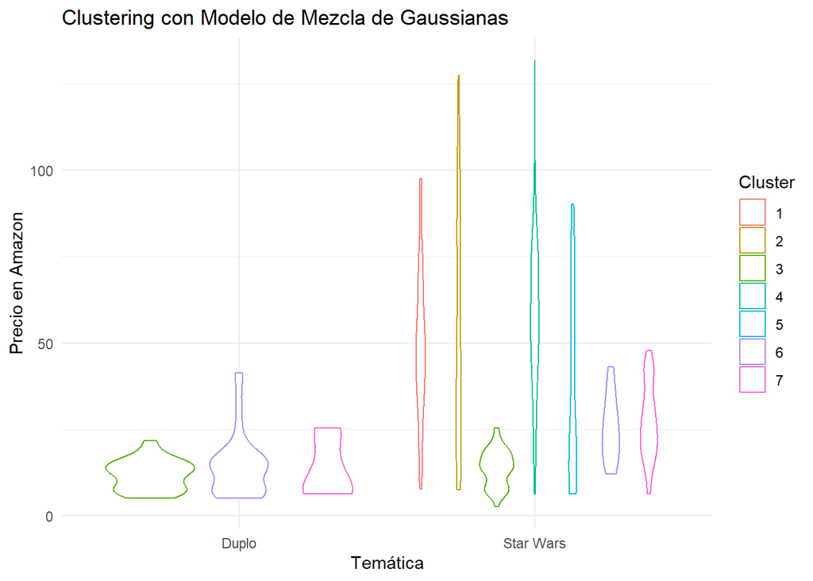

```r
ggplot(seleccion, aes(x = Theme, y = Amazon_Price, color = factor(cluster))) +
  geom_violin(method = "lm", aes(color = factor(cluster))) +
  labs(title = "Clustering con Modelo de Mezcla de Gaussianas",
       x = "Temática",
       y = "Precio en Amazon",
       color = "Cluster") +
  theme_minimal()
```

El gráfico nos comparte cómo varía el precio en Amazon para las temáticas “Star Wars” y “Duplo” dentro de cada cluster. Esto nos proporciona una perspectiva más detallada sobre cómo se distribuyen los precios para cada temática y cómo difieren entre los diferentes clusters.

La clusterización de los temas de Star Wars y Duplo según sus características nos proporciona una valiosa información para entender mejor el mercado, optimizar nuestras estrategias comerciales y desarrollar productos más acordes a las necesidades de los clientes.

Al agrupar productos similares dentro de cada tema, la clusterización nos permite tener una visión más clara de las preferencias y demandas de los consumidores. Esto nos capacita para adaptar estratégicamente nuestras tácticas de marketing y ventas, abordando de manera más efectiva las necesidades específicas de cada segmento del mercado.

Además, al comprender mejor qué características son más valoradas por los consumidores en los juegos de LEGO, podemos utilizar la clusterización como una guía para el desarrollo de nuevos productos. Esto nos ayuda a dirigir nuestros esfuerzos hacia la creación de productos que estén alineados con las preferencias y expectativas del mercado, asegurando una mayor aceptación por parte de nuestros clientes.